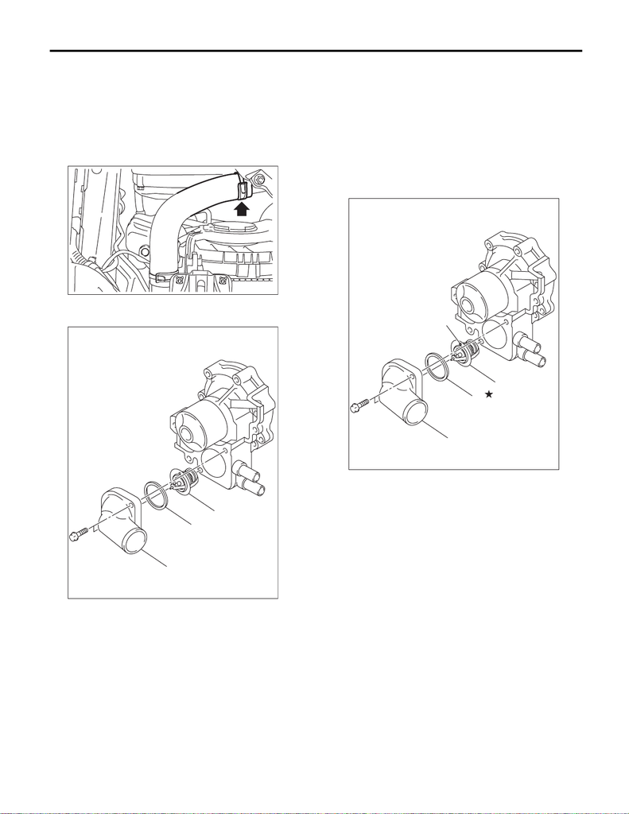

CO(STI)-17

Thermostat

COOLING

5. Thermostat

A: REMOVAL

1) Drain engine coolant. <Ref. to CO(STI)-13,

DRAINING OF ENGINE COOLANT, REPLACE-

MENT, Engine Coolant.>

2) Disconnect the radiator outlet hose from thermo-

stat cover.

3) Remove the thermostat cover, and then remove

the gasket and thermostat.

B: INSTALLATION

1) Install a gasket to thermostat.

NOTE:

Use a new gasket.

2) Install the thermostat and thermostat cover.

NOTE:

Install the parts with the jiggle pin facing upward.

Tightening torque:

12 N·m (1.2 kgf-m, 8.9 ft-lb)

3) Connect the radiator outlet hose to thermostat

cover.

4) Install the under cover. <Ref. to EI-22, INSTAL-

LATION, Front Under Cover.>

5) Lower the vehicle.

6) Fill engine coolant. <Ref. to CO(STI)-13, FILL-

ING OF ENGINE COOLANT, REPLACEMENT,

Engine Coolant.>

(A) Thermostat cover

(B) Gasket

(C) Thermostat

CO-02771

CO-02780

(B)

(A)

(C)

(A) Thermostat cover

(B) Gasket

(C) Thermostat

(D) Jiggle pin

CO-02781

(B)

(A)

(C)

(D)

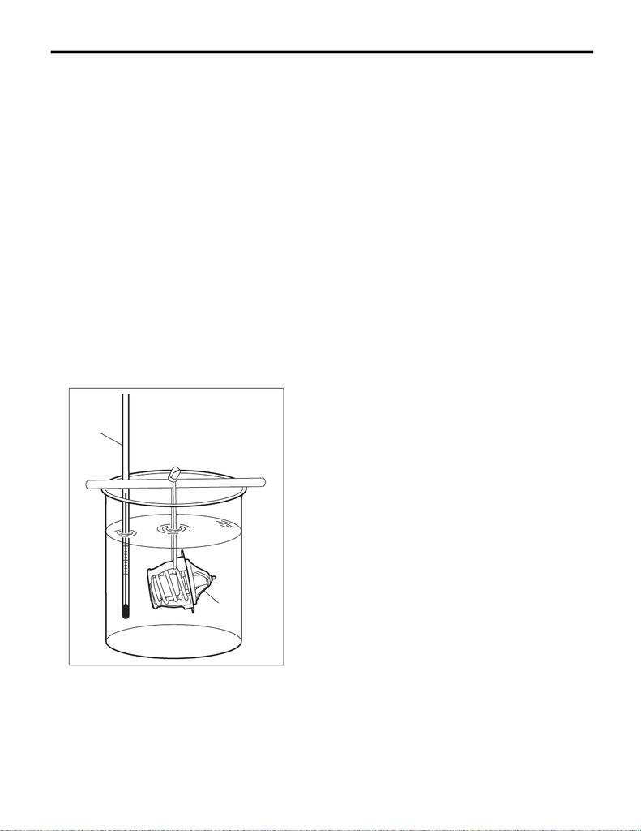

CO(STI)-18

Thermostat

COOLING

C: INSPECTION

1) Check that the thermostat does not have defor-

mation, cracks or damage.

2) Check that the thermostat valve closes com-

pletely at an ambient temperature.

3) Immerse the thermostat and a thermometer in

water. Raise water temperature gradually, and

check the temperature and valve lift when the valve

begins to open and when the valve is fully opened.

Replace the thermostat if faulty.

NOTE:

• During the test, agitate the water for even tem-

perature distribution.

• Leave the thermostat in the boiling water for five

minutes or more before measuring the valve lift.

• Hold the thermostat with a wire or the like to

avoid contacting the container.

Starting temperature to open:

76 — 80°C (169 — 176°F)

Full open temperature:

91°C (196°F)

Total valve lift:

9.0 mm (0.354 in) or more

(A) Thermometer

(B) Thermostat

CO-02420

(A)

(B)